# Wines Exploration by José Gildo

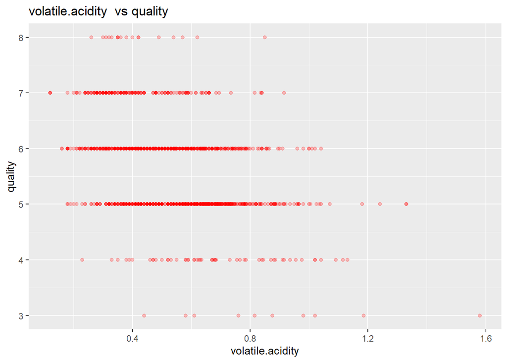

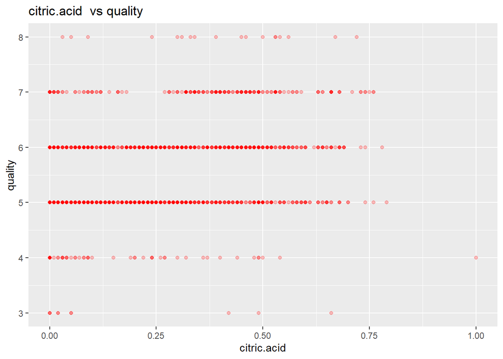

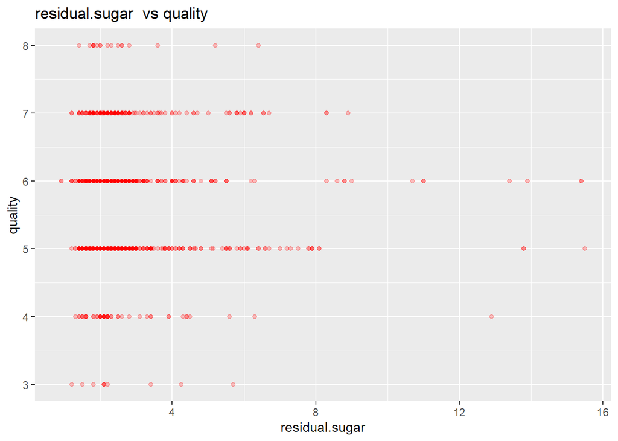

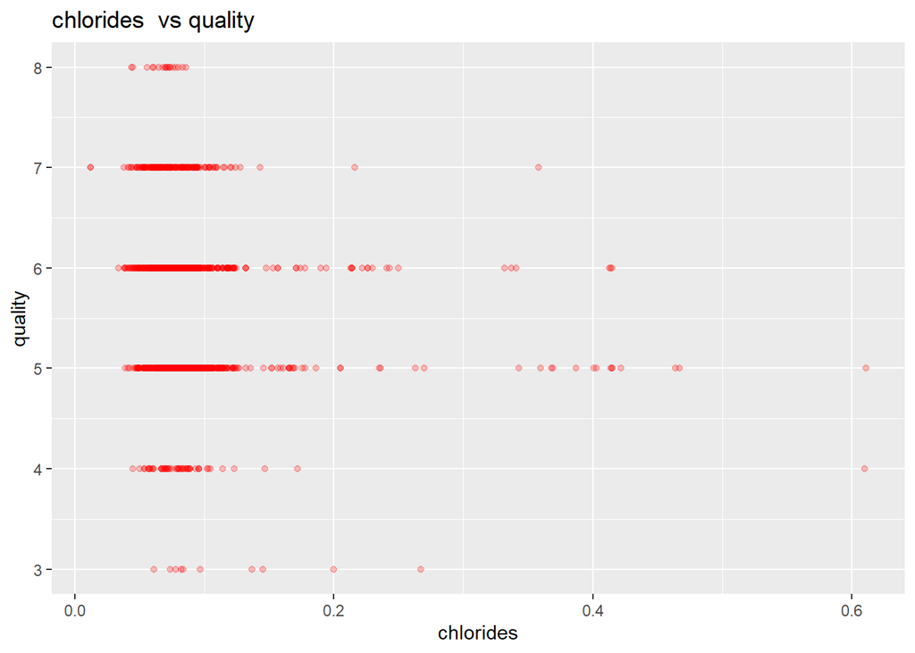

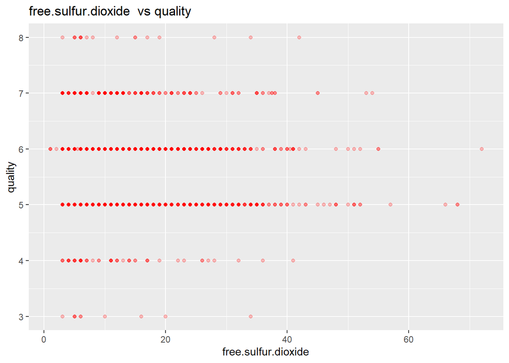

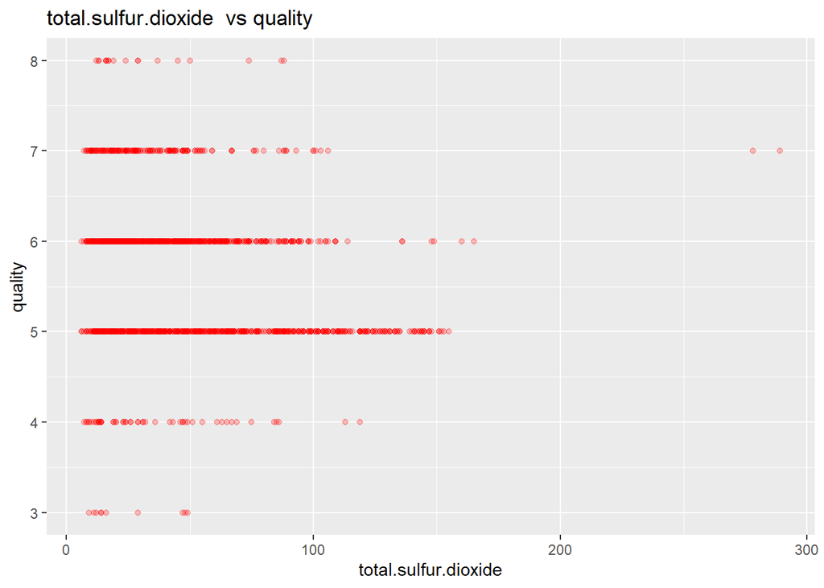

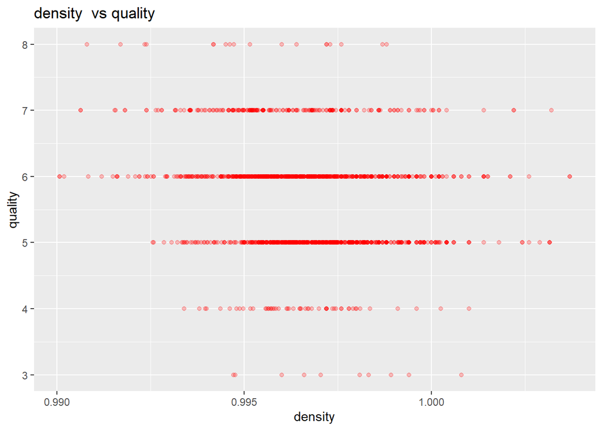

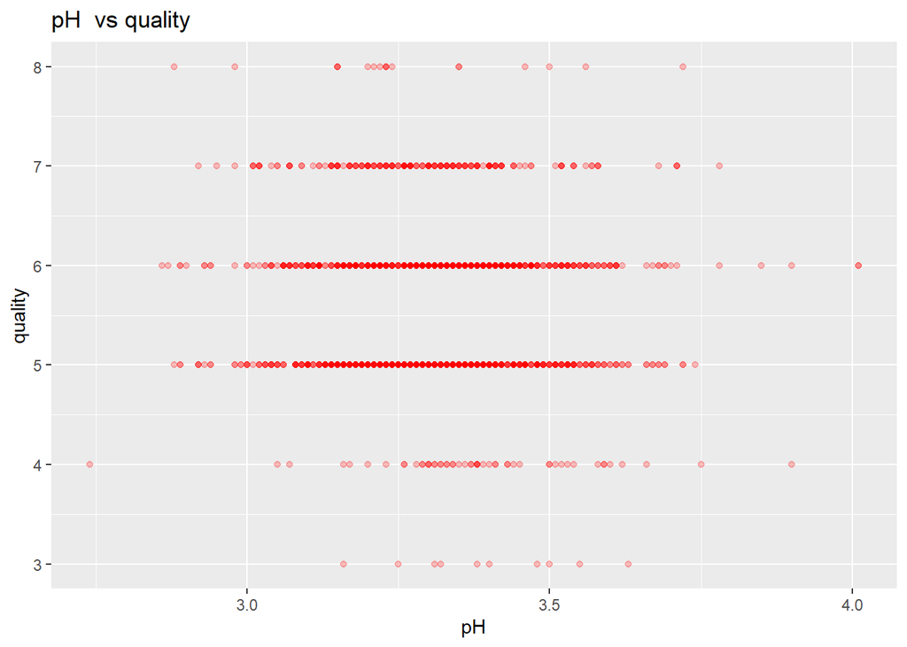

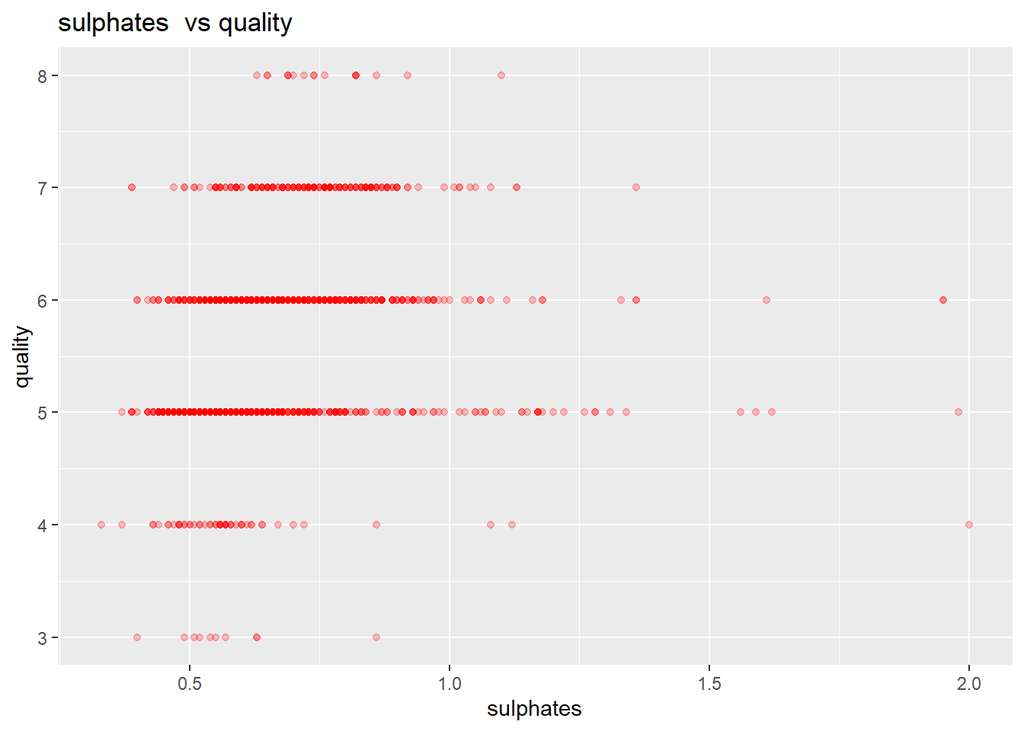

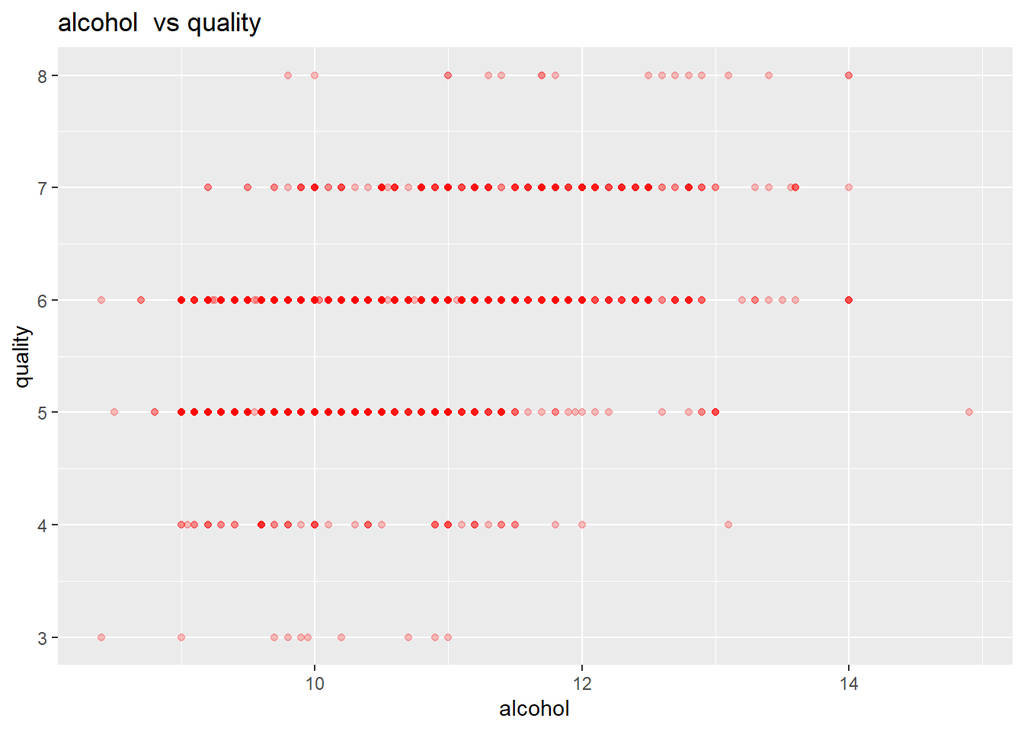

**White Wines:**

Now we are interested in understanding the behavior of quality over other variables considering just white wines.

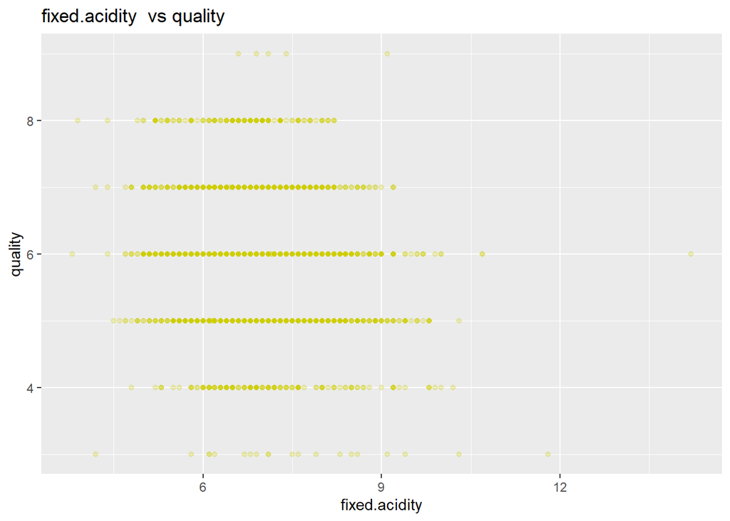

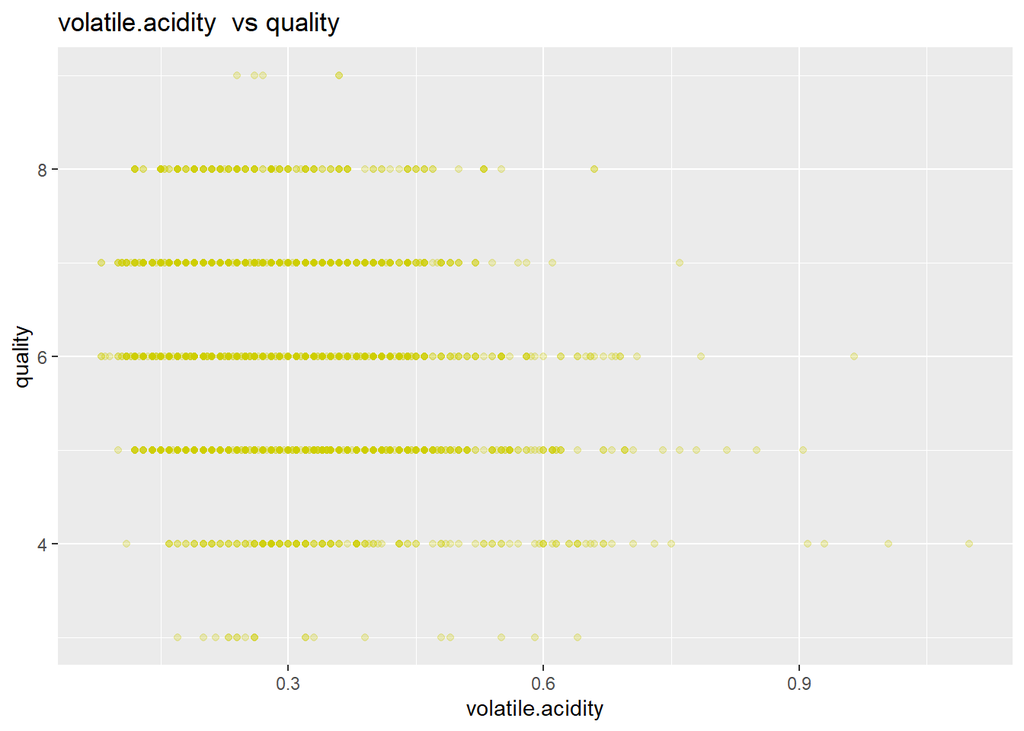

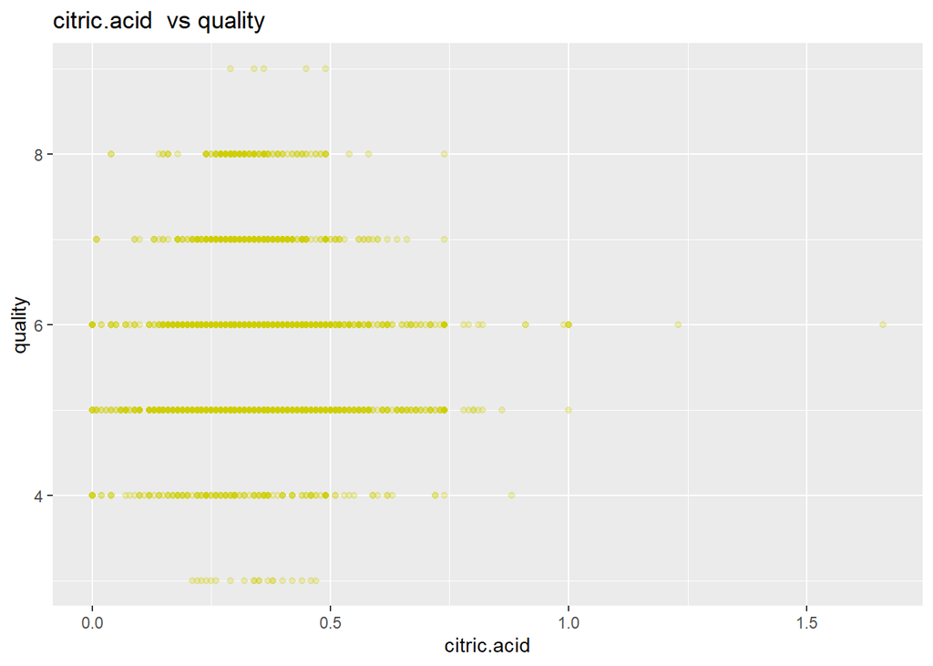

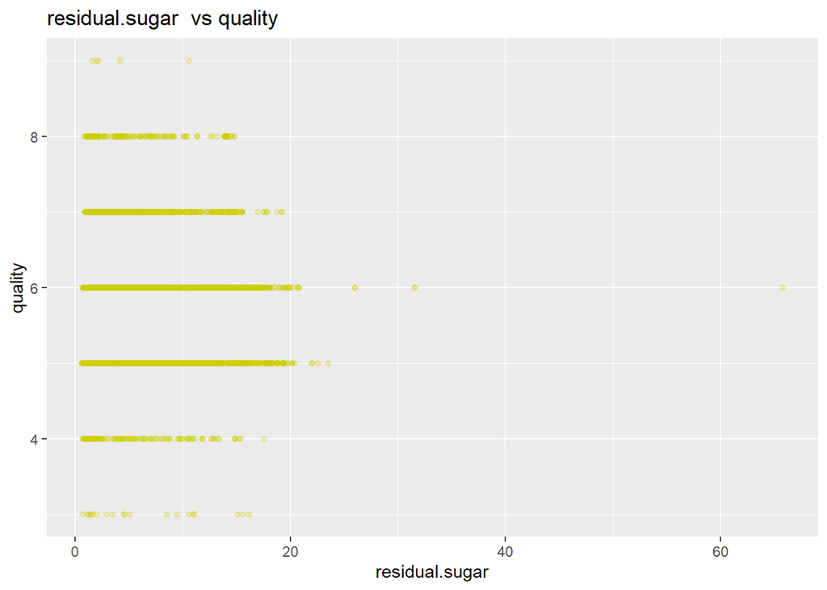

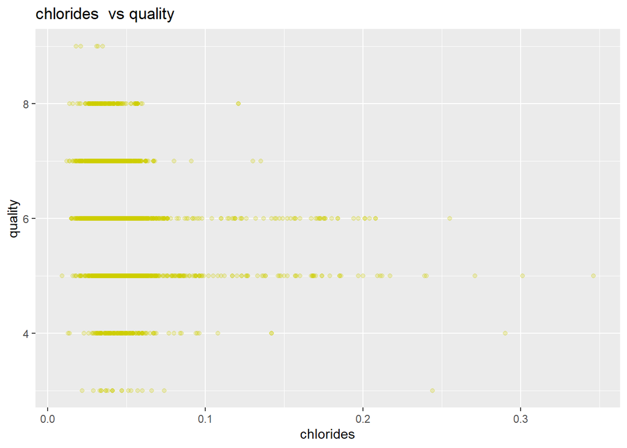

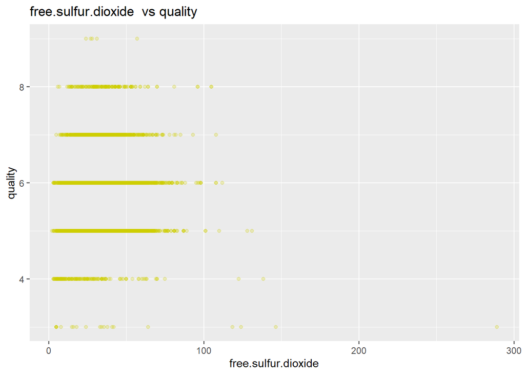

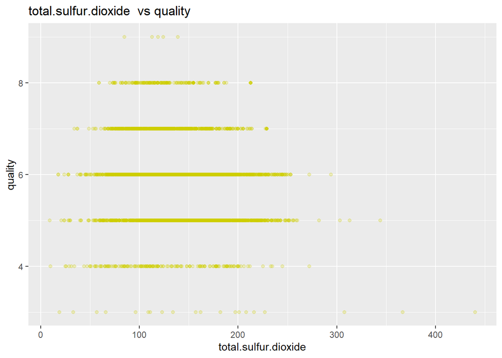

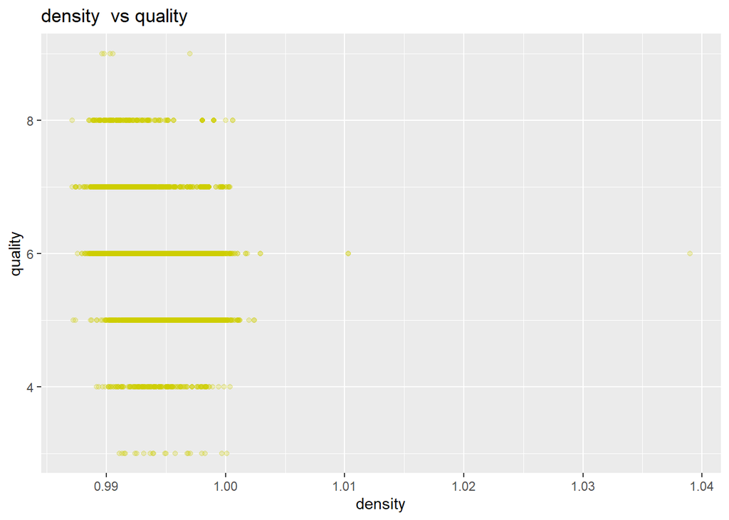

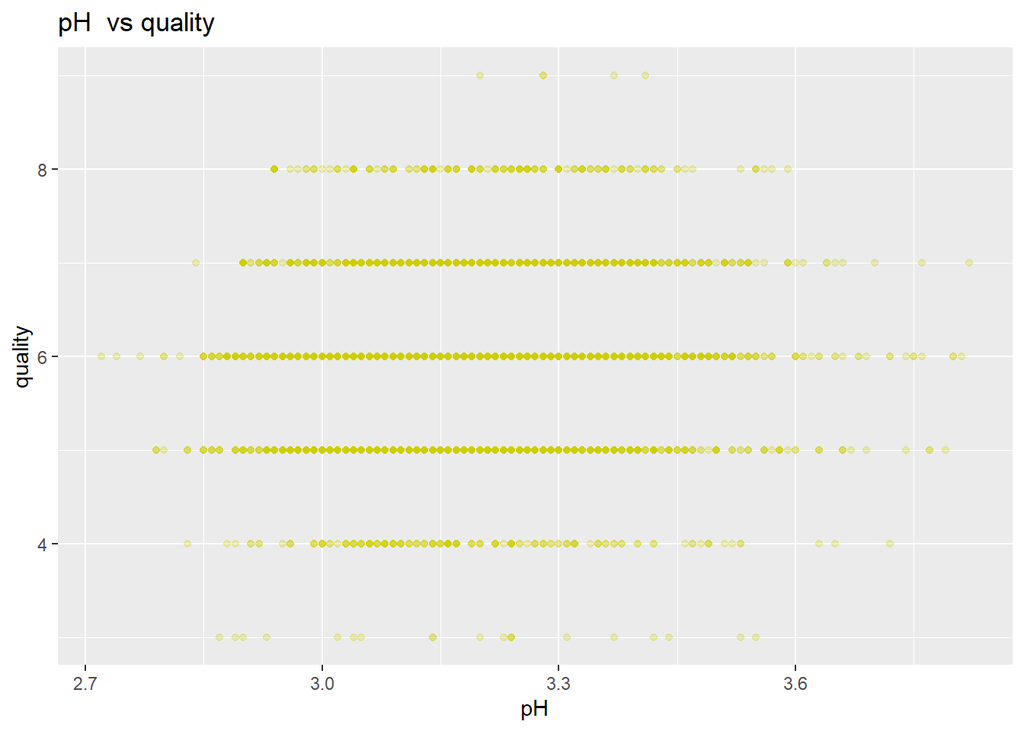

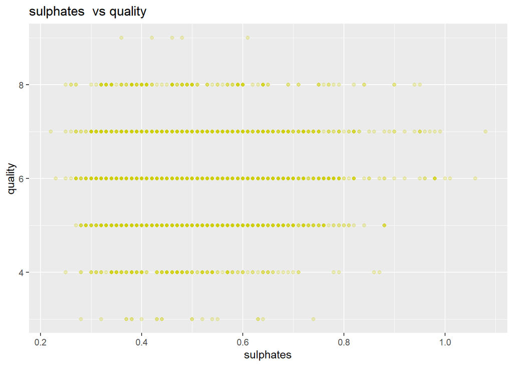

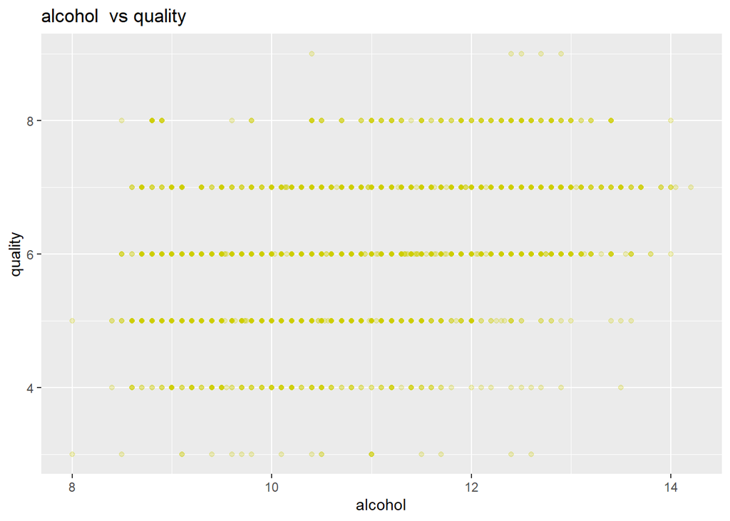

### Plot One

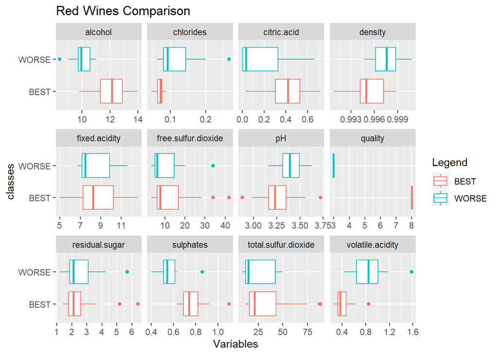

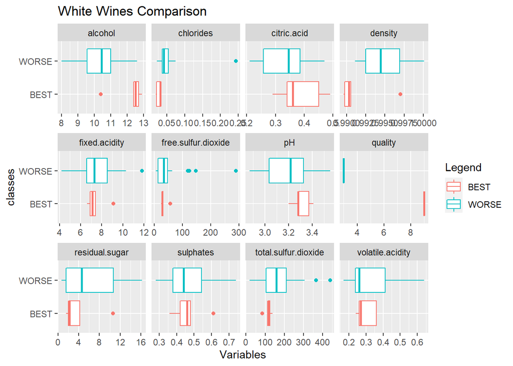

## Conclusions

**Red Wines** If we observe just red wines, maximum *quality* it is obtained when:

- **Alcohol** > 10 (in the most of the cases);
- **Density** < 1;
- **Fixed Acid** < 13;
- Low **volatility** > 0.2 < 0.9;
- If we analyze *Free Sulfur Dioxide, Total Sulfur, Fixed Sulfur* and *Residual Sugar* best and worst quality have similar proportions of these elements and it is unlikely these variables can determine quality in red wines. At the same time, we found maximum quality with *ph* lower than 3 and upper 3.5. Perhaps, *ph* be the result of the combination of other variables and not necessarily a determining variable.

- The variables are more defined than red wines;
- **Alcohol** > 10 < 13;
- **Ph** > 3.15 < 3.5
- **Volatility** > 0.2 < 0.4
- **Fixed Acid** > 6 < 9
- **Chlorides** < 0.05
- **Density** > 0.9 < 1
- **Sulphates** > 0.3 < 0.7

# Bivariate Analysis

> **Tip**: As before, summarize what you found in your bivariate explorations here. Use the questions below to guide your discussion.

### What was the strongest relationship you found?

# Multivariate Plots Section

> **Tip**: Now it’s time to put everything together. Based on what you found in the bivariate plots section, create a few multivariate plots to investigate more complex interactions between variables. Make sure that the plots that you create here are justified by the plots you explored in the previous section. If you plan on creating any mathematical models, this is the section where you will do that.

# Multivariate Analysis

### Were there any interesting or surprising interactions between features?

# Final Plots and Summary

> **Tip**: You’ve done a lot of exploration and have built up an understanding of the structure of and relationships between the variables in your dataset. Here, you will select three plots from all of your previous exploration to present here as a summary of some of your most interesting findings. Make sure that you have refined your selected plots for good titling, axis labels (with units), and good aesthetic choices (e.g. color, transparency). After each plot, make sure you justify why you chose each plot by describing what it shows.

### Plot One

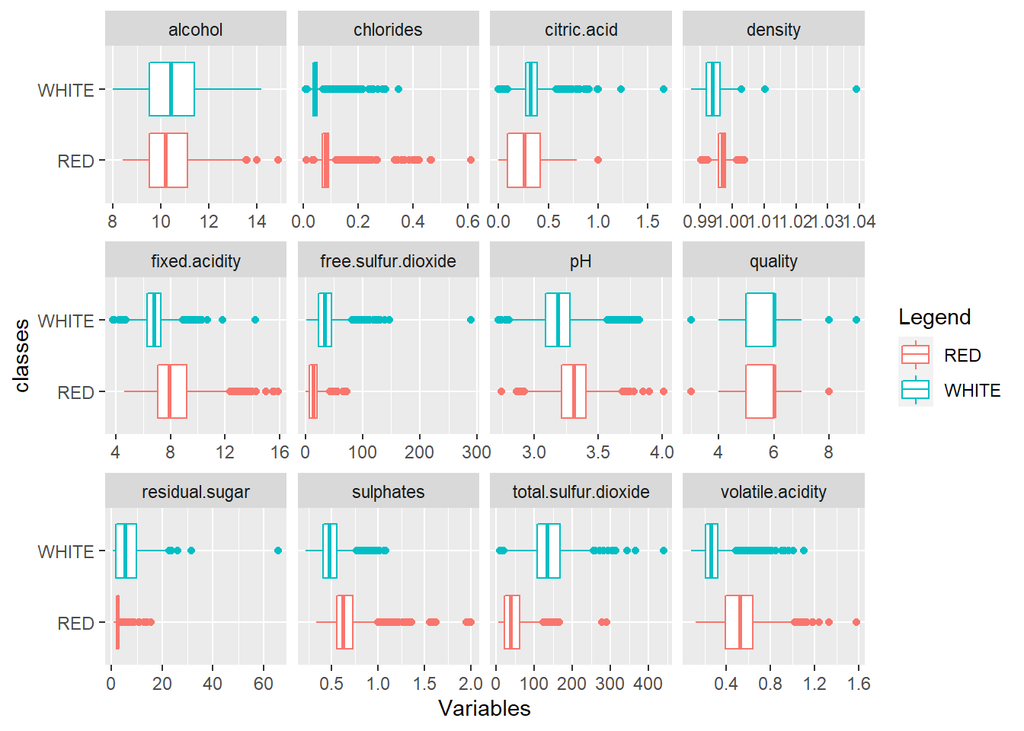

# Reflection

> **Tip**: Here’s the final step! Reflect on the exploration you performed and the insights you found. What were some of the struggles that you went through? What went well? What was surprising? Make sure you include an insight into future work that could be done with the dataset.

> **Tip**: Don’t forget to remove this, and the other **Tip** sections before saving your final work and knitting the final report!